# Recommendation Engines - Group Assignment 01

MBD Term 2 - O17 (Group G)

07/03/2019

## Introduction and Data Loading

Testing several algorithms on these datasets will allow to identify which algorithm is the most adapted to the business cases, as well as finding which parameters provide the best results.

In order to achieve the desired level of analysis and also to have an efficient execution time, we subset the `bigMovieLense` by taking 1/3 of the dataset.

```
## [1] "Groceries Dataset:"
```

```
## 1 x 169 rating matrix of class 'binaryRatingMatrix' with 4 ratings.
```

```
## [1] "bigMovieLense Dataset:"
```

```
## 1 x 2000 rating matrix of class 'realRatingMatrix' with 40 ratings.
```

## Data Preparation

The `bigMovieLense` dataset needs to be binarized in order to explore different algorithms. The `Groceries` dataset is already in the right format and can be analyzed without preleminary preparation.

```
## [1] "Binarized bigMOvieLense:"
```

```
## 1 x 2000 rating matrix of class 'binaryRatingMatrix' with 40 ratings.
```

Both datasets are then split into **train**, **test *known*** and **test *unknown*** sets using the **evaluationScheme** function.

```
## [1] "Groceries Sets:"
```

```
## 8847 x 169 rating matrix of class 'binaryRatingMatrix' with 38886 ratings.
```

```
## 988 x 169 rating matrix of class 'binaryRatingMatrix' with 988 ratings.
```

```
## 988 x 169 rating matrix of class 'binaryRatingMatrix' with 3493 ratings.
```

```
## [1] "bigMovieLense Sets:"
```

```
## 1800 x 2000 rating matrix of class 'binaryRatingMatrix' with 159174 ratings.
```

```
## 200 x 2000 rating matrix of class 'binaryRatingMatrix' with 19269 ratings.
```

```
## 200 x 2000 rating matrix of class 'binaryRatingMatrix' with 199 ratings.
```

## Pipeline

The datasets being ready, a procedure can be defined to proceed them in a consistent way, evaluate each recommendation algorithm, and decide which one is the most adapted to the business case.

The set of algorithms to be tested is:

- Popular
- ALS
- AR
- IBCF
- UBCF

Each algorithm family requires a different set of parameters, which will be set and tuned by multiple functions to find the best combination. Some of these parameters are:

- methods including **Cosine**, **Pearson** and **Jaccard**,
- **k** parameter referring to the number of neighbours to be considered while calculating the similarity values,
- **nn** parameter referring to the neighbourhood size used by the algorithm,
- **support** parameter referring to the number of rules coming out of the association rules algorithm,
- **confidence** parameter referring to the number of rules resulting from the association rules algorithm.

To identify the best set of parameters for each algorithm family, their **ROC Curves** will be plotted to compare the performance of the models.

Then, to compare the algorithm families, their best algorithms’ ROC Curves will be plotted on a common figure.

In order to support the choice of the final algorithm, two (2) additional tools will help drawing a conclusion:

- An **evaluation summary** presenting key-metrics, like *True Positive (TP)*, *True Negative (TN)*, *Precision*, *Recall*. The *Accuracy* is also included by calculation.
- A customer-focused analysis, which aims understanding the benefits of the models from a business point of view.

## Groceries Analysis

*Note: the main scripts store the datasets resulting from the algorithms in the folder `RDS_GROCERIES`. They are loded from there to avoid running them to generate this report.*

The following charts show the ROC curves for each algorithm, plotting them for each value of the parameters that have been tested. It allows to select the best parameter value for each algorithm, considering that the highest curve is the best one.

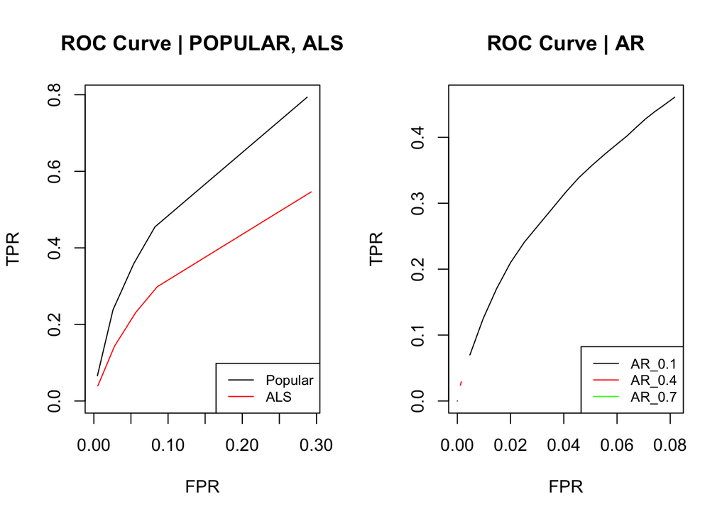

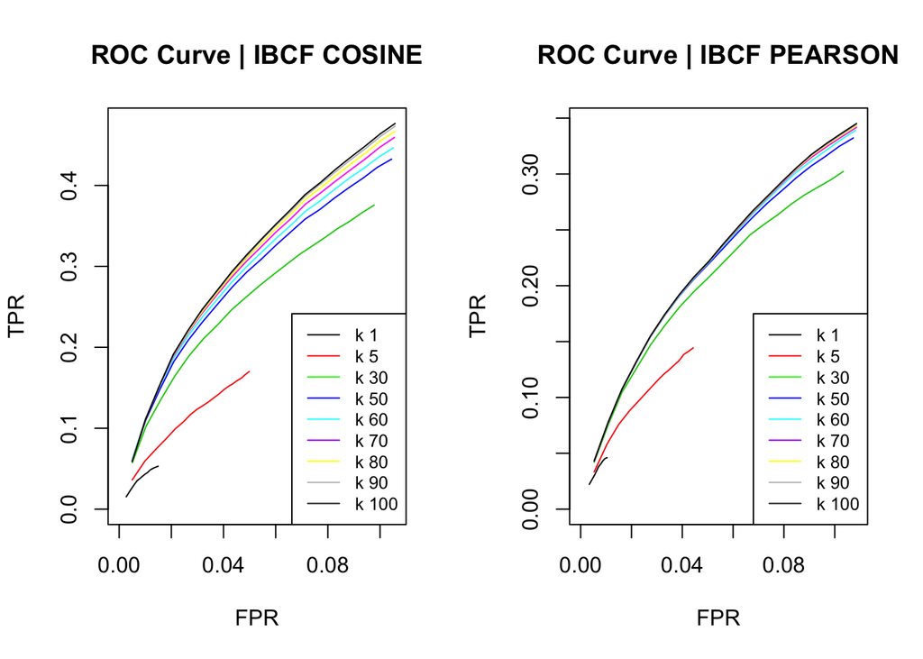

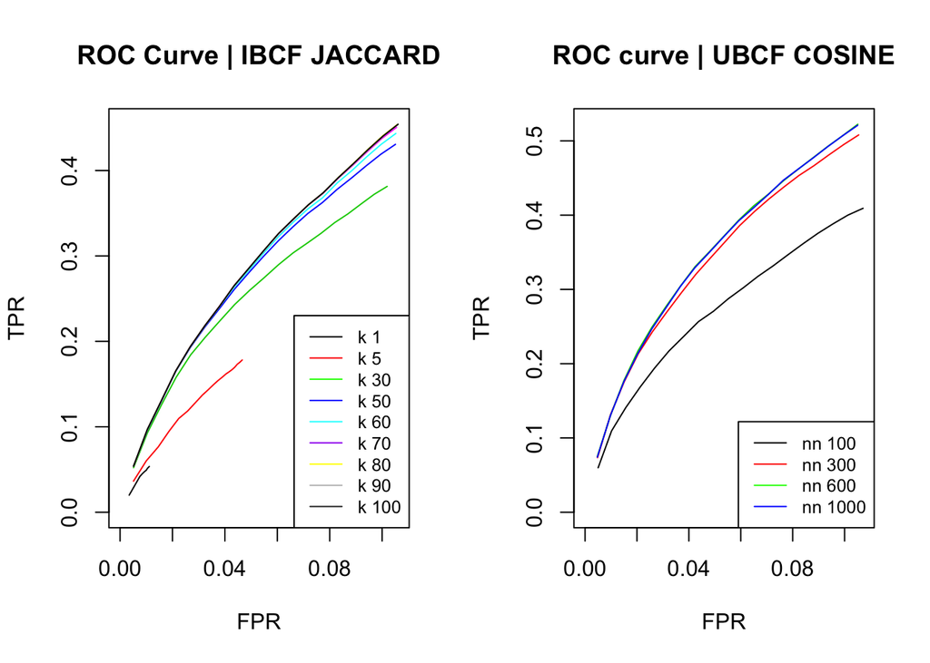

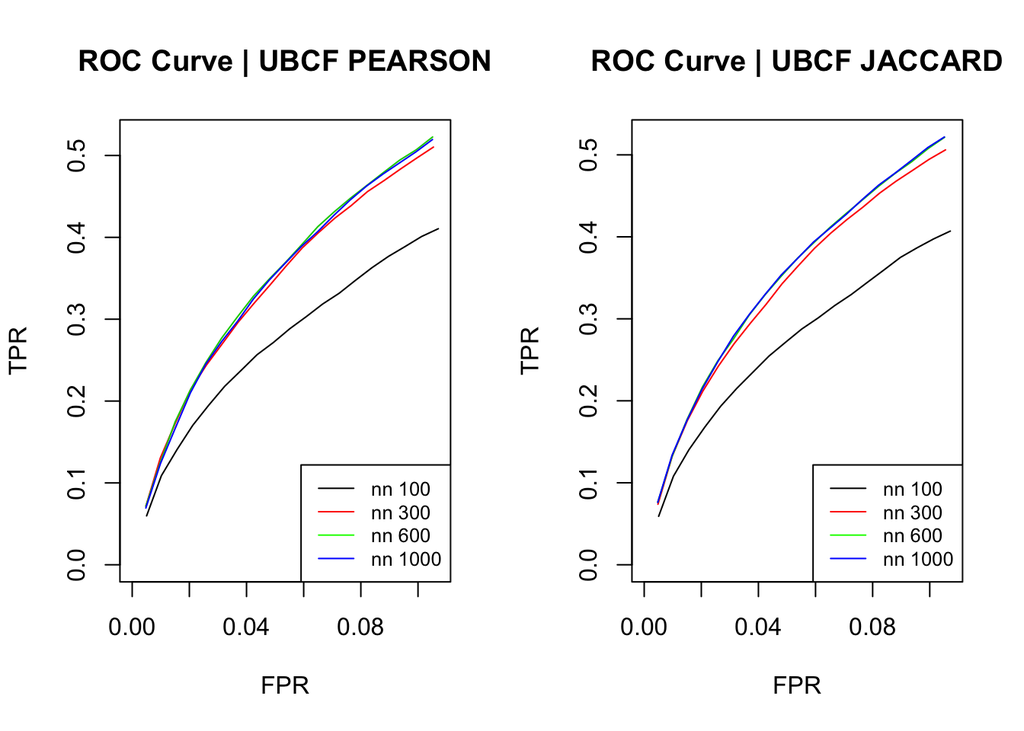

For this dataset, `Popular` is performing really well. We assume that it is because, in this dataset, most of the consumers buy popular basic products, regardless of brands, tastes… such as rice, bread, milk, fruits…

Regarding `Item Based Collaborative Filtering (IBCF)`, the `Cosine` method provides better results, even though they are close to the `Jaccard` method results. Also, bigger is the `k` parameter, better the result is.

For the `User Based Collaborative Filtering (UBCF)`, the three (3) methods look really close, regardless of the parameter value. Also, the larger the parameter `nn` is, the better the results of the model, but we reach a ceiling pretty fast.

Selecting the best parameter for each algorithm, it is possible to compare the algorithms on the same chart.

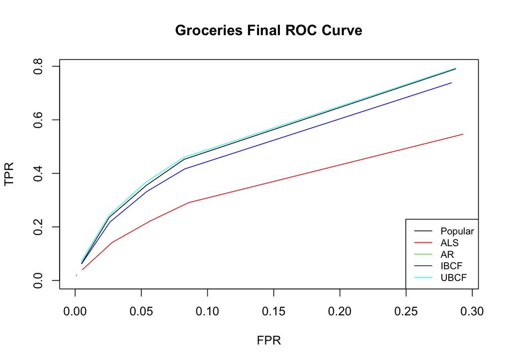

Looking at the Accuracy and the Precision, the `AR` model provides better predictions than other algorithms. It makes sense regarding our case, as for grocery products, we should check Association Rules to understand how consumers combine their purchase habits. It is one of the best way to get insights on consumers baskets, especially for recurrent products and purchases.

```
##                 TP        FP       FN       TN PRECISION     RECALL
## POPULAR 1.16093117 8.8390688 2.374494 155.6255 0.1160931 0.35809591
## ALS     0.58299595 9.4170040 2.952429 155.0476 0.0582996 0.17813924
## AR      0.07489879 0.2004049 3.460526 164.2642 0.2707424 0.02152215
## IBCF    1.06680162 8.9261134 2.468623 155.5385 0.1066802 0.34307592
## UBCF    1.16700405 8.8329960 2.368421 155.6316 0.1167004 0.37507316
##                TPR        FPR  ACCURACY
## POPULAR 0.35809591 0.05362886 0.9332526
## ALS     0.17813924 0.05721013 0.9263724
## AR      0.02152215 0.00121894 0.9782087
## IBCF    0.34307592 0.05417626 0.9321742
## UBCF    0.37507316 0.05359609 0.9333249
```

## bigMovieLense Analysis

*Note: the main scripts store the datasets resulting from the algorithms in the folder `RDS_BML_SUBSET`. They are loded from there to avoid running them to generate this report.*

The following charts show the ROC curves for each algorithm, plotting them for each value of the parameters that have been tested. It allows to select the best parameter value for each algorithm, considering that the highest curve is the best one.

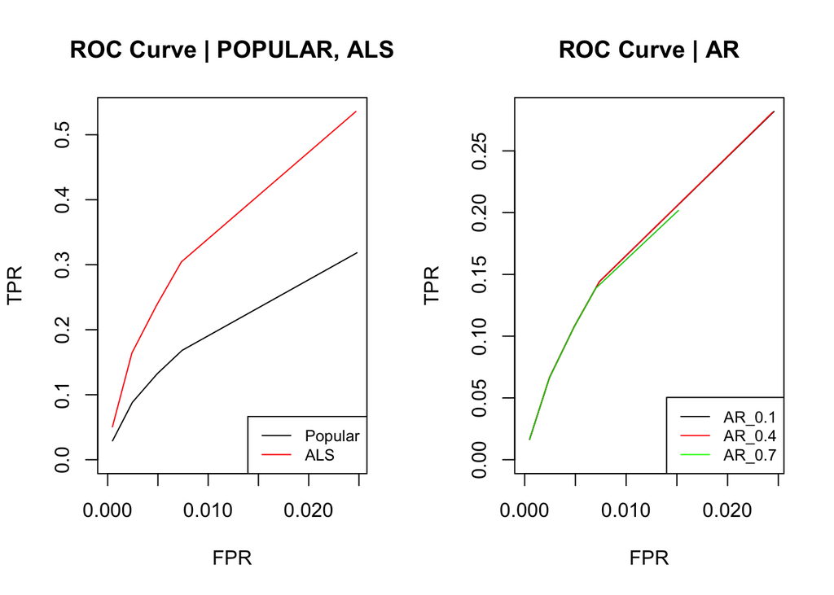

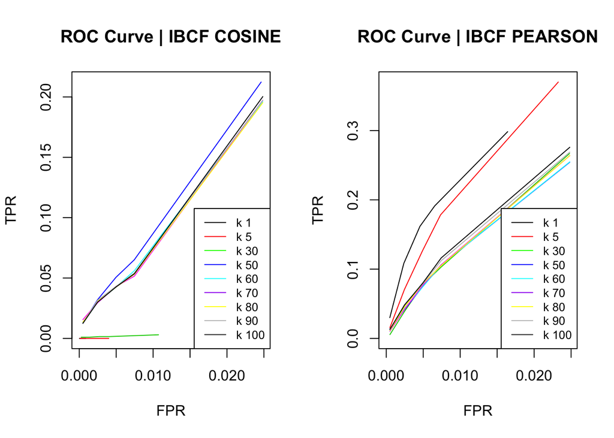

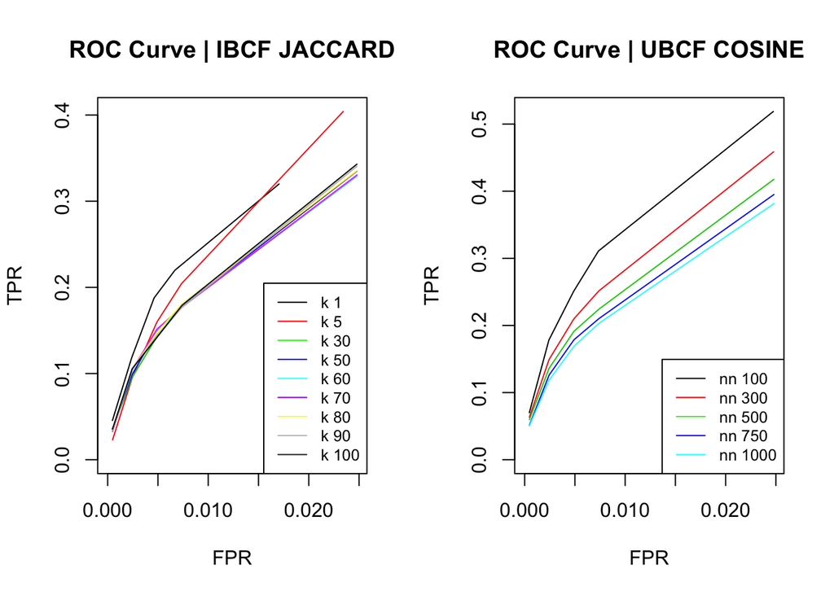

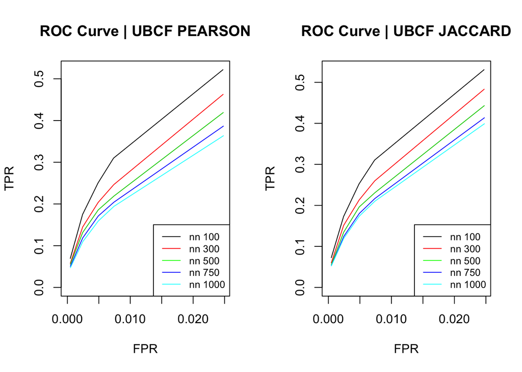

For this dataset, `ALS` is performing far better than `Popular`. In the case of movies, where tastes can evolve in time really fast, Popularity is useful only for the first steps of the users on the platform. In the long-run, it will decrease in performance.

For the `AR`, the confidence 0.7 helps to narrow down the options shown to the users, in order to be as personalised as possible.

Selecting the best parameter for each algorithm, it is possible to compare the algorithms on the same chart.

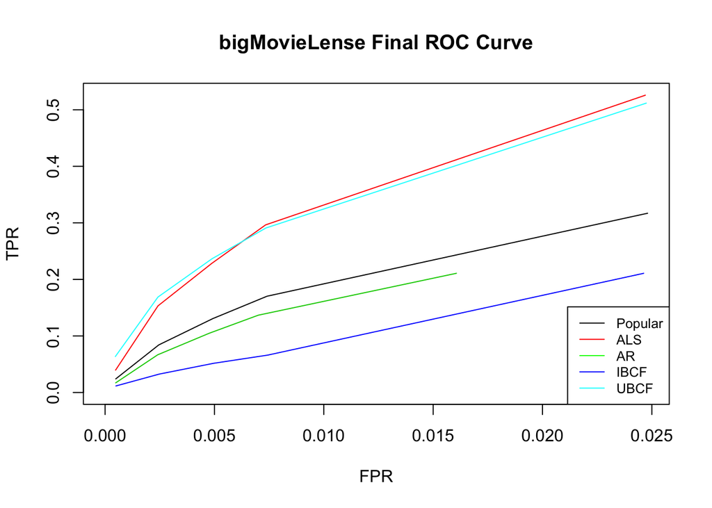

Looking at the Accuracy and the Precision, the `UBCF` model provides better predictions than other algorithms, even though every algorithm are really close in performance. Based on that, our deciding factor will be heavily weighted towards the business value. In that case, `UBCF` allows to provide predictions highly customised to the user preferences in reference to similar users. For further work, a combination of `UBCF` and `IBCF` should provide a more holistic approach towards our customers and a more complete scope for our recommendation engine.

```
##            TP    FP    FN       TN   PRECISION     RECALL        TPR
## POPULAR 0.115 9.835 0.880 1990.170 0.011557789 0.11557789 0.11557789
## ALS     0.035 9.965 0.960 1990.040 0.003500000 0.03517588 0.03517588
## AR      0.090 9.760 0.905 1990.245 0.009137056 0.09045226 0.09045226
## IBCF    0.030 9.910 0.965 1990.095 0.003015075 0.03015075 0.03015075
## UBCF    0.245 9.755 0.750 1990.250 0.024500000 0.24623116 0.24623116
##                 FPR  ACCURACY
## POPULAR 0.004917500 0.9946452
## ALS     0.004982488 0.9945402
## AR      0.004880000 0.9946702
## IBCF    0.004955000 0.9945652
## UBCF    0.004877488 0.9947501
```

## Results Analysis

The two (2) datasets don’t response the same way to the different algorithms. It is mainly due to their intrinsec characterisics. The `Groceries` dataset relates to daily products, for which tastes might not be as disparate than for movies. This repetitive and consistent behaviour explains why the `AR` model is more efficient with the `Groceries` dataset compared to the `bigMovieLense`.

###### *Vratul Kapur | Irune Maury Arrue | Paul Jacques-Mignault | Sheena Miles | Ashley O’Mahony | Stavros Tsentemeidis | Karl Westphal*

###### *O17 (Group G) | Master in Big Data and Business Analytics | Oct 2018 Intake | IE School of Human Sciences and Technology*